# Lab_6

Kim Youngrae

2016년 11월 14일

# Contents

- Olympic decathlon data
- Stock Price data
- DIJA Data

# Olympic decathlon data

책 499p 에 있는 이 자료는, 올림픽 10종 경기의 기록에 대한 자료이다. 우리는 Correlation Matrix를 가지고 Factor analysis를 하려고 한다. (Example 9.6)

```r
setwd("/Users/kyr0302/Desktop/Lab_6")
data<-read.table("E9-6.dat")
data
```

```
##         V1     V2      V3     V4     V5     V6     V7     V8     V9
## 1   1.0000 0.6386  0.4752 0.3227 0.5520 0.3262 0.3509 0.4008 0.1821
## 2   0.6386 1.0000  0.4953 0.5668 0.4706 0.3520 0.3998 0.5167 0.3102
## 3   0.4752 0.4953  1.0000 0.4357 0.2539 0.2812 0.7926 0.4728 0.4682
## 4   0.3227 0.5668  0.4357 1.0000 0.3449 0.3503 0.3657 0.6040 0.2344
## 5   0.5520 0.4706  0.2539 0.3449 1.0000 0.1546 0.2100 0.4213 0.2116
## 6   0.3262 0.3520  0.2812 0.3503 0.1546 1.0000 0.2553 0.4163 0.1712
## 7   0.3509 0.3998  0.7926 0.3657 0.2100 0.2553 1.0000 0.4036 0.4179
## 8   0.4008 0.5167  0.4728 0.6040 0.4213 0.4163 0.4036 1.0000 0.3151
## 9   0.1821 0.3102  0.4682 0.2344 0.2116 0.1712 0.4179 0.3151 1.0000
## 10 -0.0352 0.1012 -0.0120 0.2380 0.4125 0.0002 0.0109 0.2395 0.0983
##        V10
## 1  -0.0352
## 2   0.1012
## 3  -0.0120
## 4   0.2380
## 5   0.4125
## 6   0.0002
## 7   0.0109
## 8   0.2395
## 9   0.0983
## 10  1.0000
```

첫번째로 Factor의 개수를 정해야 한다. 우리가 선택할 수 있는 방법은 다음과 같다.

- Scree plot
- Number of eigenvalue > C for some C
- Cumulative variation
- Hypothesis test

앞의 세가지는 모두 eigenvalue와 관련된 사항이므로, 먼저 eigen decomposition을 해보자.

```r
eig.res<-eigen(data)
eig.res$values
```

```
##  [1] 4.2129434 1.3895855 1.0594001 0.9177767 0.6698798 0.5757197 0.4210947
##  [8] 0.3219537 0.2525054 0.1791411
```

eigenvalue는 위와 같으므로, 선택하기 나름이지만, 1을 넘는 것까지 선택하면 3개의 Factor, 0.9 이상으로 선택하면, 4개의 Factor를 사용할 수 있다. Scree plot을 그려보면 다음과 같다.

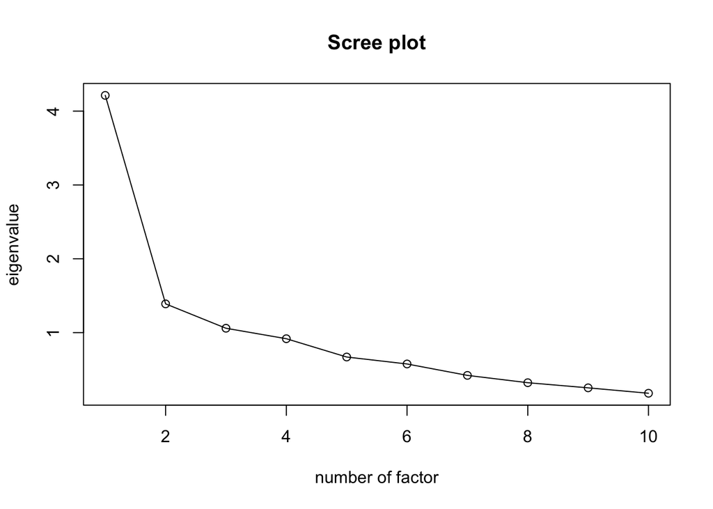

```r
plot(1:10,eig.res$values, main="Scree plot", ylab="eigenvalue", xlab="number of factor")
lines(1:10,eig.res$values)
```

Scree plot으로 확인할 때는, Scree plot이 평평해질때쯤 Stop하고 Factor의 개수를 정한다고 알려져 있는데, 이는 주관적인 선택이 된다.

Hypothesis test의 경우, 저번시간에 이용했던 factanal 함수의 도움을 받아서 확인해보자. (이는 자료 모두가 필요함, 공분산행렬만 가지고는 하지 못하는것 같음.) Eigenvalue들을 기반으로 하여 Factor의 개수를 3개로 결정한 다음 Factor analysis를 진행하면 다음처럼 할 수 있다.

```r
fa.res<-factanal( ~. , factors = 3 , covmat = as.matrix(data))
fa.res
```

```
##
## Call:
## factanal(x = ~., factors = 3, covmat = as.matrix(data))
##
## Uniquenesses:
##    V1    V2    V3    V4    V5    V6    V7    V8    V9   V10
## 0.005 0.399 0.083 0.414 0.549 0.796 0.311 0.401 0.736 0.766
##
## Loadings:
##       Factor1 Factor2 Factor3
##  [1,]  0.224   0.968
##  [2,]  0.347   0.608   0.333
##  [3,]  0.915   0.281
##  [4,]  0.363   0.302   0.603
##  [5,]          0.578   0.331
##  [6,]  0.219   0.308   0.248
##  [7,]  0.809   0.179
##  [8,]  0.386   0.373   0.558
##  [9,]  0.476           0.167
## [10,]                  0.482
##
##                Factor1 Factor2 Factor3
## SS loadings      2.227   2.086   1.226
## Proportion Var   0.223   0.209   0.123
## Cumulative Var   0.223   0.431   0.554
##
## The degrees of freedom for the model is 18 and the fit was 0.3117
```

결과로 Loading과 Proportion, Cumlative Variation이 나오는데, 3개의 Factor를 이용해서는 55.4% 정도를 차지하고 있는 것을 알 수있다. Cumulative Variation을 이용해 Factor의 개수를 선택하는 경우에는 더 많은 Factor가 필요하게 된다.

Factor analysis의 목적으로 변수들의 Clustering을 생각할 수 있다. loading을 확인해 보면, Factor1에는 3, 7, 9번째 변수, Factor2에는 1, 2, 5 번째 변수, Factor3에는 4, 8, 10 번째 변수를 묶으면 좋을 것 같다.

변수 설명을 보면, 첫번째 변수부터 순서대로 100m, Long jump, Shot put, High jump, 400m, 110m huddle, Discus, Pole vault, Javelin, 1500m 이다.

우리가 묶은 Factor들의 변수를 확인해보면,

Factor1은 Shot put, Discus, Javelin으로, 무거운 것을 던지는 능력으로 확인할 수 있다.

Factor2는 100m, Long jump, 400m 인데, Long jump가 포함되어 있지만, 100m, 400m가 함께 포함된 것으로 보아, 단거리 달리기 능력과 관련있을거라 생각할 수 있다.

Factor3은 High jump, Pole vault, 1500m 인데, 역시 1500m가 껴있지만, 나머지 두개는 높이뛰기 종목이다. 따라서 그와 관련이 있는것으로 확인할 수 있다.

```r
fa.res.4<-factanal(~., factors=4, covmat = as.matrix(data))
fa.res.4
```

```
##
## Call:
## factanal(x = ~., factors = 4, covmat = as.matrix(data))
##
## Uniquenesses:
##    V1    V2    V3    V4    V5    V6    V7    V8    V9   V10
## 0.010 0.388 0.089 0.327 0.196 0.734 0.304 0.420 0.725 0.600
##
## Loadings:
##       Factor1 Factor2 Factor3 Factor4
##  [1,]  0.205   0.296   0.928
##  [2,]  0.280   0.554   0.451   0.155
##  [3,]  0.883   0.278   0.228
##  [4,]  0.254   0.739           0.242
##  [5,]  0.142   0.151   0.519   0.701
##  [6,]  0.136   0.465   0.173
##  [7,]  0.794   0.220   0.133
##  [8,]  0.314   0.612   0.168   0.279
##  [9,]  0.477   0.160           0.139
## [10,]          0.111           0.619
##
##                Factor1 Factor2 Factor3 Factor4
## SS loadings      1.958   1.719   1.471   1.057
## Proportion Var   0.196   0.172   0.147   0.106
## Cumulative Var   0.196   0.368   0.515   0.621
##
## The degrees of freedom for the model is 11 and the fit was 0.0578
```

Factor의 개수가 적어 제대로 군집화를 못하는 것일수도 있어 4개로 해보았을때의 결과는 위와 같다.

Factor1 : 3(Shot put), 7(Discus), 9(Javelin)

Factor2 : 2(Long jump), 4(High jump), 6(110m huddle), 8(Pole vault)

Factor3 : 1(100m), 2(Long jump), 5(400m)

Factor4 : 5(400m), 10(1500m)

Factor를 4개로 늘렸을 때는 비교적 더 잘 분류해내는 것을 확인할 수 있다. 던지기 / 점프 / 단거리 / 장거리 정도로 해석할 수 있을것 같다.

Factor analysis의 목적으로 첫번째 변수의 Clustering을 확인했는데, Factor score에 관련된 이야기 역시 중요하다. Factor score의 경우, 다차원의 자료를 낮은차원의 자료로 축소하여 표현할 수 있고(압축의 의미), 이를 이용해 각 관측치를 Clustering 할 수도 있다.

Factor score는 각각의 Observation마다 주어지는 값이며, Data가 완전히 주어져야 구해낼 수 있는 값이므로, 우리가 지금까지 본 예제와 같이 Correlation, 또는 Covariance 행렬만 주어진 경우에는 알수 있는 값들이 아니다. 이를 위해 저번시간에 같이 살펴본 Stock Price data를 확인해보자.

# Stock Price data

책 473p 에 있는 이 자료는, 5개의 회사의 수익률에 대한 자료이다. 역시 Correlation Matrix를 이용해 분석해보자. (Example 9.5)

```r
data<-read.table("T8-4.dat")
colnames(data)<-c("JP Morgan","Citibank","Wells Fargo","Royal Dutch Shell","Exxon Mobil")
head(data)
```

```
##    JP Morgan   Citibank Wells Fargo Royal Dutch Shell Exxon Mobil
## 1  0.0130338 -0.0078431  -0.0031889        -0.0447693   0.0052151
## 2  0.0084862  0.0166886  -0.0062100         0.0119560   0.0134890
## 3 -0.0179153 -0.0086393   0.0100360         0.0000000  -0.0061428
## 4  0.0215589 -0.0034858   0.0174353        -0.0285917  -0.0069534
## 5  0.0108225  0.0037167  -0.0101345         0.0291900   0.0409751
## 6  0.0101713 -0.0121978  -0.0083768         0.0137083   0.0029895
```

```r
cor<-cor(data)
cor
```

```
##                   JP Morgan  Citibank Wells Fargo Royal Dutch Shell
## JP Morgan         1.0000000 0.6322878   0.5104973         0.1146019
## Citibank          0.6322878 1.0000000   0.5741424         0.3222921
## Wells Fargo       0.5104973 0.5741424   1.0000000         0.1824992
## Royal Dutch Shell 0.1146019 0.3222921   0.1824992         1.0000000
## Exxon Mobil       0.1544628 0.2126747   0.1462067         0.6833777
##                   Exxon Mobil
## JP Morgan           0.1544628
## Citibank            0.2126747
## Wells Fargo         0.1462067
## Royal Dutch Shell   0.6833777
## Exxon Mobil         1.0000000
```

Factor의 개수를 정하기 위해, Eigen decomposition을 한다.

```r
eig.res<-eigen(cor)
eig.res$values
```

```
## [1] 2.4372731 1.4070127 0.5005127 0.4000316 0.2551699
```

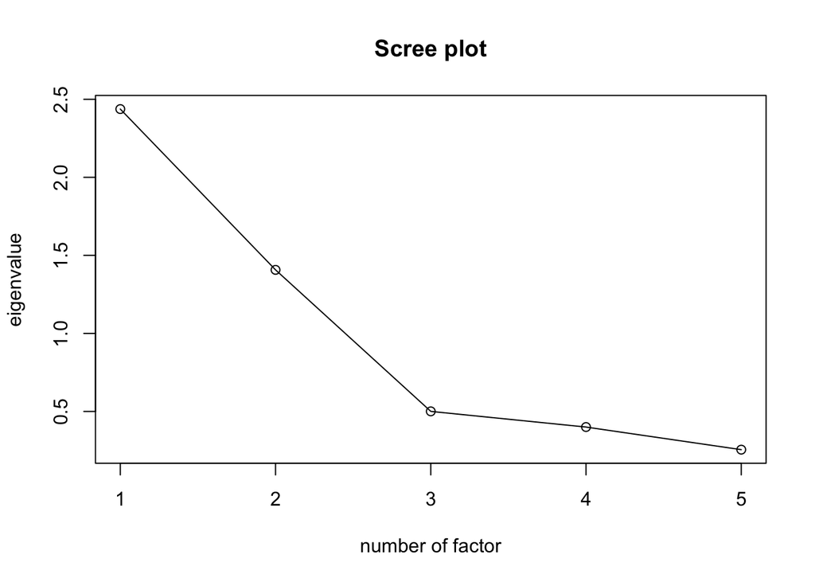

```r
plot(1:5,eig.res$values, main="Scree plot", ylab="eigenvalue", xlab="number of factor")
lines(1:5,eig.res$values)
```

이러한 결과를 확인해보았을 때 2개의 Factor가 있으면 적절하다는 것을 알 수 있다. Factor의 개수를 2개로 정한 뒤 Factor analysis를 진행하면,

```r
fa.res<-factanal(data,factors=2)
```

먼저 우리의 첫번째 목적인 변수의 Clustering을 위해 Loading을 확인해보면,

```r
fa.res$loadings
```

```
##
## Loadings:
##                   Factor1 Factor2
## JP Morgan         0.763
## Citibank          0.819   0.232
## Wells Fargo       0.668   0.108
## Royal Dutch Shell 0.113   0.991
## Exxon Mobil       0.108   0.677
##
##                Factor1 Factor2
## SS loadings      1.725   1.507
## Proportion Var   0.345   0.301
## Cumulative Var   0.345   0.646
```

Factor1 : JP Morgan, Citibank, Wells Fargo

Factor2 : Royal Dutch Shell, Exxon Mobil

이렇게 연관되어 있는것을 알 수 있다. Factor1에 속한 JP Morgan, Citibank, Wells Fargo는 모두 미국의 은행, 금융업계의 회사이고, Factor2에 속한 Royal Dutch Shell과 Exxon Mobil은 석유회사이다. 이처럼 두개의 Factor로 나뉘며, 이들은 다른 산업군에 있음을 확인할 수 있다.

이제 Factor Score에 대한 이야기를 해보자. Factor Score는 우리의 가정이 잘 맞는지를 확인해주는 척도로 사용될 수 있다. Factor Score를 먼저 추정해보자. 여기서는 WLS 방법을 이용해본다.

```r
fa.res.score<-factanal(data,factors=2,scores="Bartlett")
score<-fa.res.score$scores
```

Score를 Plot해보자, 우리의 가정에서 Score는 평균이 0, 분산이 1이어야 하고, 서로 독립이어야 한다.

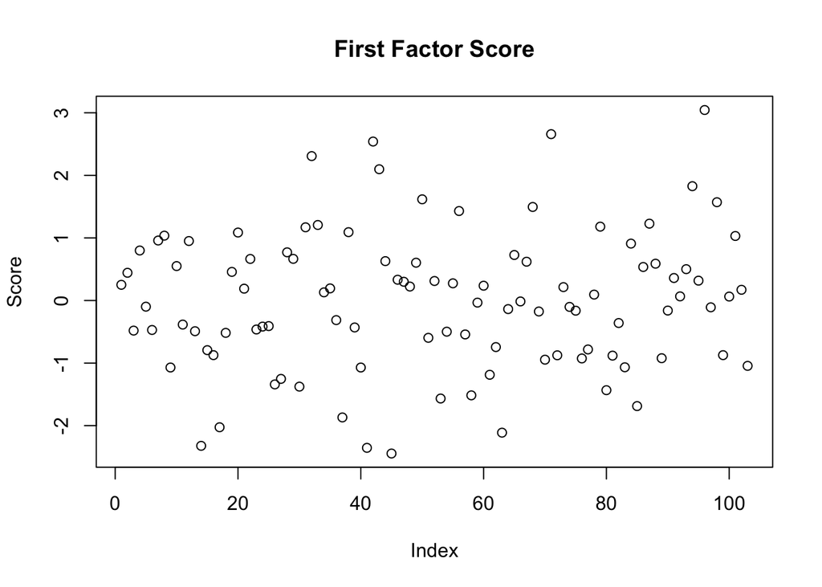

```r
plot(score[,1],main="First Factor Score", ylab="Score")
```

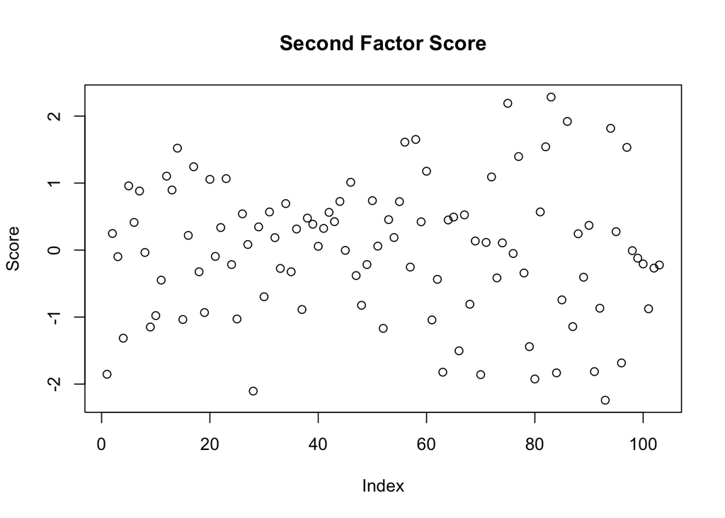

```r
plot(score[,2],main="Second Factor Score", ylab="Score")
```

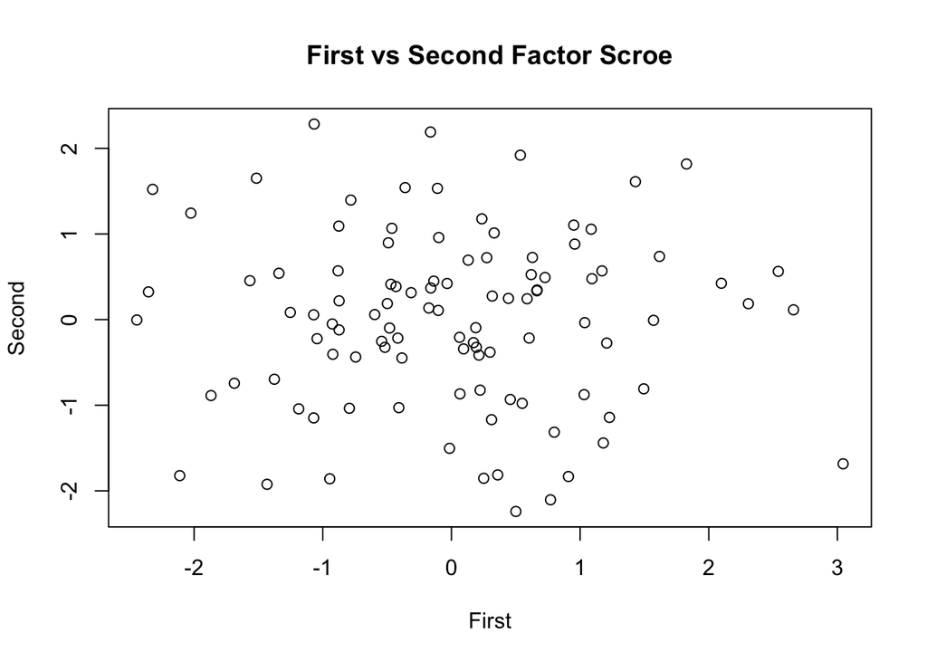

```r
plot(score[,1],score[,2],
     main="First vs Second Factor Scroe", ylab="Second",xlab="First")
```

이렇게 위의 그림으로 우리의 가정이 들어맞고 있음을 확인할 수 있다.

Factor Score는 이렇게 가정의 확인 이상의 의미를 가질 수 있는데, 자료를 적은 차원으로 표현하는 용도로 사용될 수 있다. 지금 사용한 자료의 예시를 들면, 우리는 Factor를 금융업계와 석유업계의 현재 상황 정도로 정의할 수 있고, 우리의 Factor Score는 각 주마다 (Observation은 주마다 기록된 값이므로) 금융권의 상황이 어떤지, 석유업계의 상황이 어떤지를 표현하는 값으로 생각할 수 있다. 예를 들면 1st Factor Score가 음수이면, 금융권의 수익률이 감소하는 것으로 해석할 수도 있다.

```r
score[100:103,]
```

```
##          Factor1    Factor2
## [1,]  0.06316369 -0.2071714
## [2,]  1.03125734 -0.8764301
## [3,]  0.17139057 -0.2691822
## [4,] -1.04440475 -0.2229043
```

```r
data[100:103,]
```

```
##      JP Morgan   Citibank Wells Fargo Royal Dutch Shell Exxon Mobil
## 100  0.0033626  0.0029016  -0.0030507        -0.0012193  -0.0097005
## 101  0.0170147  0.0095061   0.0181994        -0.0161758  -0.0075614
## 102  0.0103929 -0.0026612   0.0044290        -0.0024818  -0.0164502
## 103 -0.0127948 -0.0143678  -0.0187402        -0.0049759  -0.0163732
```

이처럼 Factor1이 크게 +인 101번째 주는 금융권의 주가가 +인 경향이고, 103번째 주는 주가가 -임을 확인할 수 있다. 반대로 Factor2는 늘 - 값을 가지지만, 101번째 주는 Factor score의 절대값이 가장 큰데, 큰폭으로 감소하는 것을 볼 수 있다. (Royal Dutch Shell의 경우.)

```r
fa.res.score$loadings
```

```
##
## Loadings:
##                   Factor1 Factor2
## JP Morgan         0.763
## Citibank          0.819   0.232
## Wells Fargo       0.668   0.108
## Royal Dutch Shell 0.113   0.991
## Exxon Mobil       0.108   0.677
##
##                Factor1 Factor2
## SS loadings      1.725   1.507
## Proportion Var   0.345   0.301
## Cumulative Var   0.345   0.646
```

Exxon Mobil은 상대적으로 영향을 받지 않고 있는데, 이는 Loading을 확인해보면 Royal Dutch Shell의 Loading이 훨씬 크기 때문에, 더 큰 관련이 있는것으로 해석해볼 수 있다.

# DIJA Data

```r
data<-read.csv("data.csv",header=FALSE)
cor<-cor(data)
eig.res<-eigen(cor)
eig.res$values
```

```
##  [1] 9.6343271 2.1418790 1.8879312 1.6582204 1.3984792 1.0737036 0.9431747
##  [8] 0.8676557 0.8341250 0.7524622 0.6907316 0.6729403 0.6211077 0.5840613
## [15] 0.5461000 0.5297202 0.5114619 0.4770185 0.4669165 0.4331787 0.4129370
## [22] 0.4038687 0.3958976 0.3869547 0.3461197 0.3295444 0.2944809 0.2500884
## [29] 0.2383877 0.2165262
```

```r
fa.res<-factanal(data,factors=6,scores="Bartlett")
```

```r
name<-read.csv("name.csv",header=TRUE)
```

Factor1 : 2, 3, 8, 19, 25

```r
as.vector(name[c(2,3,8,19,25),3])
```

```
## [1] "AmericanExpress"            "AmericanInternationalGroup"
## [3] "Citigroup"                  "JPMorganChase"
## [5] "BankofAmericaCorporation"
```

Factor2 : 1, 4, 6, 10, 27

```r
as.vector(name[c(1,4,6,10,27),3])
```

```
## [1] "AmericanAirlines"       "3M"
## [3] "Caterpillar"            "EIduPontdeNemoursandCo"
## [5] "UnitedTechnologies"
```

Factor3 : 18, 21, 23

```r
as.vector(name[c(18,21,23),3])
```

```
## [1] "Johnson&Johnson" "Merck"           "Pfizer"
```

Factor4 : 14, 16, 22

```r
as.vector(name[c(14,16,22),3])
```

```
## [1] "Hewlett-PackardCompany" "Intel"
## [3] "Microsoft"
```

Factor5 : 24, 28

```r
as.vector(name[c(24,28),3])
```

```
## [1] "AT&T"    "Verizon"
```

Factor6 : 7, 11

```r
as.vector(name[c(7,11),3])
```

```
## [1] "Chevron"    "ExxonMobil"
```